# PSTAT 10 Worksheet 6 Solutions

## Problem 1: Estimating a binomial expectation

Let $X$ be the r.v. that indicates the number heads after flipping a *biased* coin $n=10$ times, where the probability of heads is $p = 0.3$.

1. In mathematical notation, write down the distribution of $X$. It should include the $\sim$ symbol.

$$X \sim \operatorname{Binom}(10,
0.3)$$

2. Estimate the expectation of $X$ through simulating $10,000$ replications

```r
mean(rbinom(10000, 10, 0.3))
```

```
## [1] 3.0034
```

## Problem 2: Plotting the binomial pmf

Recall the pmf of a discrete r.v. $X$ is given by
$$f(k) = \mathbb{P}(X = k).$$
Just to reiterate the notation, $f$ is a function of $k$, the outcome of a random experiment of which $X$ is a numerical value (e.g. number of heads); $f$ is the pmf of $X$.

The plot of a pmf gives a good idea of the “shape” of a distribution; it is often informative to look at the plot.

Recreate the following plot of the pdf of $X\sim \mathrm{Binom(10, 0.18)}$.

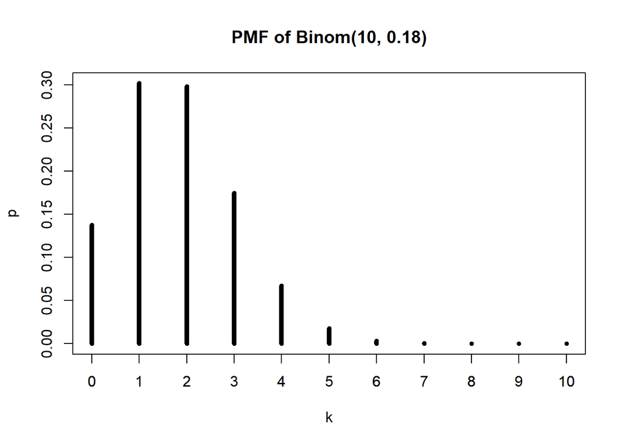

```r
plot(0:10, dbinom(0:10, size = 10, prob = 0.18),
     main = "PMF of Binom(10, 0.18)",
     ylab = "p", xlab = "k", type = "h", lwd = 5)
axis(side = 1, at = 0:10)
```

## Problem 3: Rolls until 15

Roll a fair six-sided die 15 times. What is the expected number of rolls it takes for the score to equal or exceed 15? Estimate using $10,000$ replications.

```r
set.seed(100)
r <- replicate(10000, which(cumsum(sample(1:6, size = 15, replace = T)) >= 15)[1])
mean(r)
```

```
## [1] 4.7546
```

If you found the above expression difficult to parse, here is it as a separate function.

```r
until_15 <- function() {
  rolls <- sample(1:6, size = 15, replace = T) # Outcome of rolling 15 dice
  c_rolls <- cumsum(rolls) # cumulative sum of rolls
  c_15 <- c_rolls >= 15 # logical vector indicates exceeding 15
  which_c_15 <- which(c_15) # Indices of cumulative scores exceeding 15
  return(which_c_15[1]) # The first such index.
}

set.seed(100)
r <- replicate(10000, until_15())
mean(r)
```

```
## [1] 4.7546
```